# Term Project

Tanveer S Bariana

December 7, 2017

In this R markdown file i will go through my results for the data science interveiw question for the prestigieous wikimedia foundation

here are the questions

1. What is our daily overall clickthrough rate? How does it vary between the groups?
2. Which results do people tend to try first? How does it change day-to-day?
3. What is our daily overall zero results rate? How does it vary between the groups?
4. Let session length be approximately the time between the first event and the last event in a session. Choose a variable from the dataset and describe its relationship to session length. Visualize the relationship.

so the folowing are my grpahs showing the overall daily click through rate and teh daily rates of Group A and B respectivly

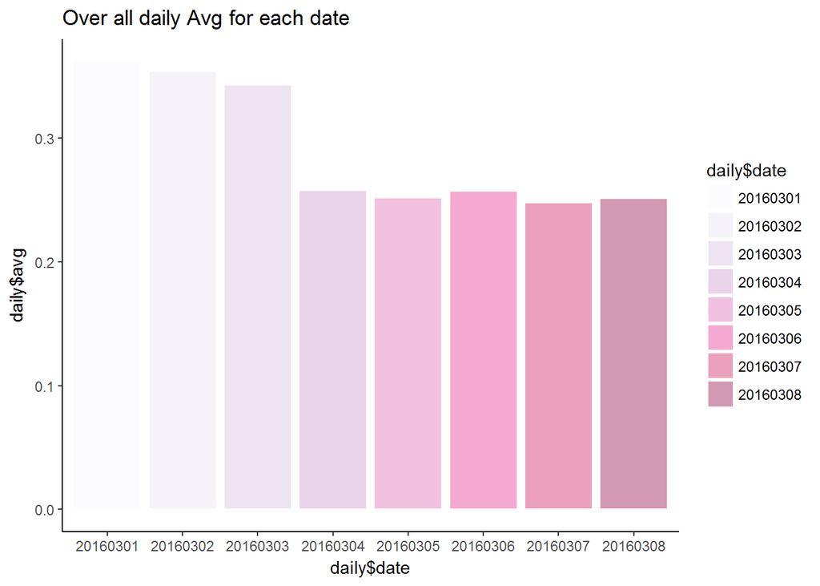

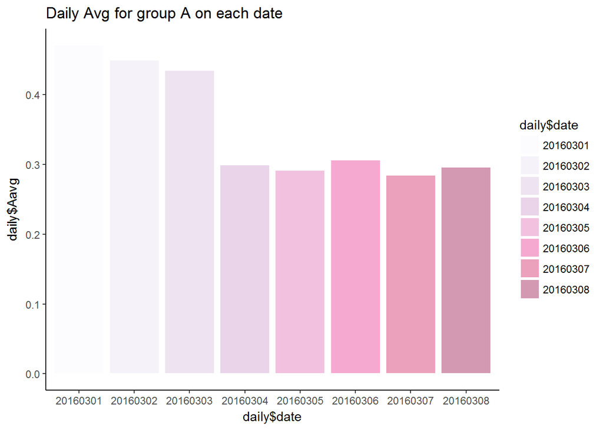

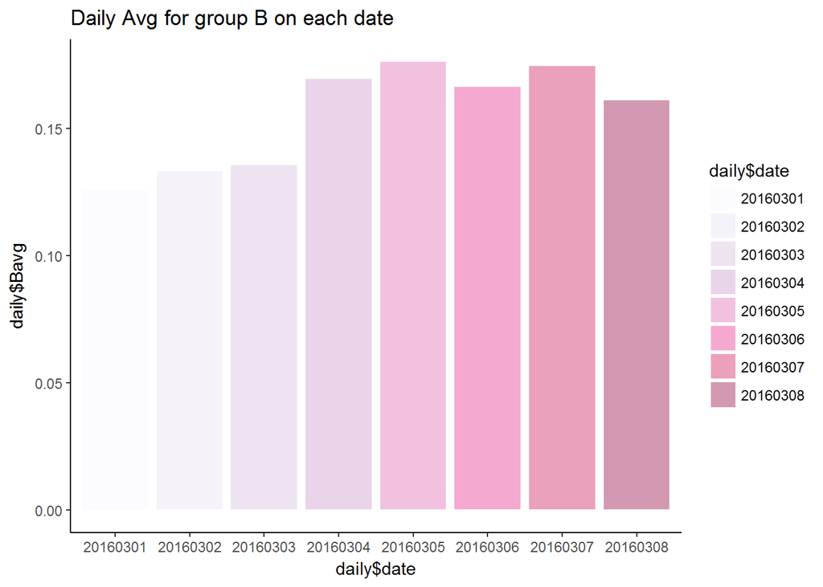

one can observe how the overal click rate and click rate for group A both decreases as time progresses but Group B increases

now we move onto graphs for the Zero result rates, and the zero result rates of groups A and B respectivly

[output not shown]

[figure not shown]

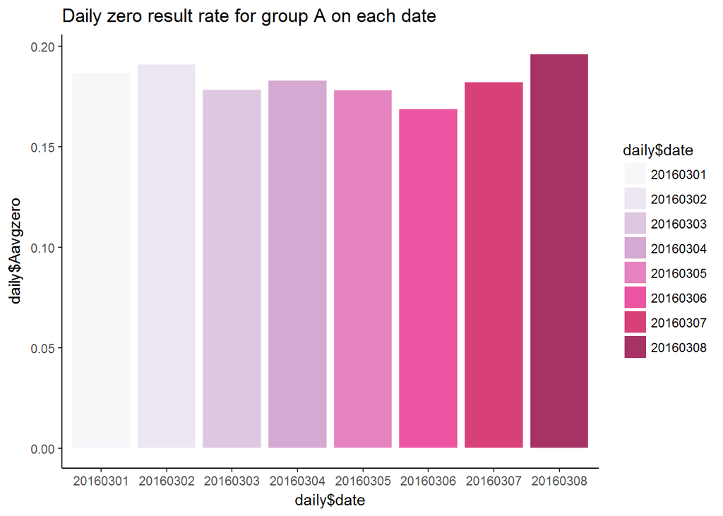

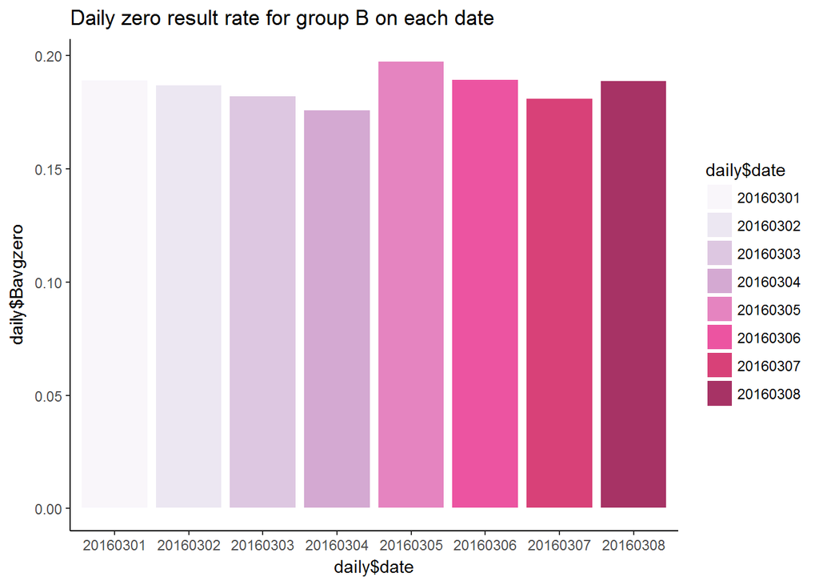